# Self-Driving Car Engineer Nanodegree

## Project: Build a Traffic Sign Recognition Classifier

In this notebook, a template is provided for you to implement your functionality in stages, which is required to successfully complete this project. If additional code is required that cannot be included in the notebook, be sure that the Python code is successfully imported and included in your submission if necessary.

In addition to implementing code, there is a writeup to complete. The writeup should be completed in a separate file, which can be either a markdown file or a pdf document. There is a [write up template](https://github.com/udacity/CarND-Traffic-Sign-Classifier-Project/blob/master/writeup_template.md) that can be used to guide the writing process. Completing the code template and writeup template will cover all of the [rubric points](https://review.udacity.com/#!/rubrics/481/view) for this project.

The [rubric](https://review.udacity.com/#!/rubrics/481/view) contains "Stand Out Suggestions" for enhancing the project beyond the minimum requirements. The stand out suggestions are optional. If you decide to pursue the "stand out suggestions", you can include the code in this Ipython notebook and also discuss the results in the writeup file.

> **Note:** Code and Markdown cells can be executed using the **Shift + Enter** keyboard shortcut. In addition, Markdown cells can be edited by typically double-clicking the cell to enter edit mode.

## Step 0: Load The Data

```python
# Load pickled data
import pickle

# TODO: Fill this in based on where you saved the training and testing data

training_file = 'C:\\Users\\stuar\\traffic-signs-data\\train.p'
validation_file= 'C:\\Users\\stuar\\traffic-signs-data\\valid.p'
testing_file = 'C:\\Users\\stuar\\traffic-signs-data\\test.p'

with open(training_file, mode='rb') as f:
    train = pickle.load(f)
with open(validation_file, mode='rb') as f:
    valid = pickle.load(f)
with open(testing_file, mode='rb') as f:
    test = pickle.load(f)

X_train, y_train = train['features'], train['labels']
X_valid, y_valid = valid['features'], valid['labels']
X_test, y_test = test['features'], test['labels']

assert(len(X_train) == len(y_train))
assert(len(X_valid) == len(y_valid))
assert(len(X_test) == len(y_test))
```

## Step 1: Dataset Summary & Exploration

The pickled data is a dictionary with 4 key/value pairs:

- `'features'` is a 4D array containing raw pixel data of the traffic sign images, (num examples, width, height, channels).
- `'labels'` is a 1D array containing the label/class id of the traffic sign. The file `signnames.csv` contains id -> name mappings for each id.
- `'sizes'` is a list containing tuples, (width, height) representing the original width and height the image.
- `'coords'` is a list containing tuples, (x1, y1, x2, y2) representing coordinates of a bounding box around the sign in the image. **THESE COORDINATES ASSUME THE ORIGINAL IMAGE. THE PICKLED DATA CONTAINS RESIZED VERSIONS (32 by 32) OF THESE IMAGES**

Complete the basic data summary below. Use python, numpy and/or pandas methods to calculate the data summary rather than hard coding the results. For example, the [pandas shape method](http://pandas.pydata.org/pandas-docs/stable/generated/pandas.DataFrame.shape.html) might be useful for calculating some of the summary results.

### Provide a Basic Summary of the Data Set Using Python, Numpy and/or Pandas

```python
### Replace each question mark with the appropriate value.
### Use python, pandas or numpy methods rather than hard coding the results

import numpy as np

# TODO: Number of training examples
n_train = X_train.shape[0]

# TODO: Number of validation examples
n_validation = X_valid.shape[0]

# TODO: Number of testing examples.
n_test = X_test.shape[0]

# TODO: What's the shape of an traffic sign image?
image_shape = X_train[0].shape

# TODO: How many unique classes/labels there are in the dataset.
n_classes = len(np.unique(y_train))

print("Number of training examples =", n_train)
print("Number of testing examples =", n_test)
print("Number of validation examples = ", n_validation)
print("Image data shape =", image_shape)
print("Number of classes =", n_classes)
```

```
Number of training examples = 34799
Number of testing examples = 12630
Number of validation examples =  4410
Image data shape = (32, 32, 3)
Number of classes = 43
```

### Include an exploratory visualization of the dataset

Visualize the German Traffic Signs Dataset using the pickled file(s). This is open ended, suggestions include: plotting traffic sign images, plotting the count of each sign, etc.

The [Matplotlib](http://matplotlib.org/) [examples](http://matplotlib.org/examples/index.html) and [gallery](http://matplotlib.org/gallery.html) pages are a great resource for doing visualizations in Python.

**NOTE:** It's recommended you start with something simple first. If you wish to do more, come back to it after you've completed the rest of the sections. It can be interesting to look at the distribution of classes in the training, validation and test set. Is the distribution the same? Are there more examples of some classes than others?

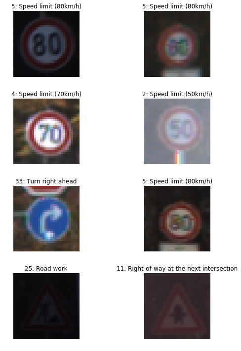

```python
### Data exploration visualization code goes here.
### Feel free to use as many code cells as needed.
import matplotlib.pyplot as plt
import random
# Visualizations will be shown in the notebook.
%matplotlib inline

signs = {}
with open("signnames.csv") as f:
    firstline = f.readline()
    for line in f:
        (key, val) = line.rstrip('\n').split(",")
        signs[int(key)] = val

fig, ax = plt.subplots(4,2, figsize=(10,10))
ax = np.ravel(ax)
for i in range(8):
    pic_num = random.randint(0, len(X_train))
    ax[i].axis('off')
    ax[i].imshow(X_train[pic_num])
    ax[i].set_title('{0}: {1}'.format(y_train[pic_num], signs[y_train[pic_num]]))
    plt.tight_layout()
```

### Class Distribution

The following graphs display the distribution of classes in the training, validation, and testing sets. The following classes occur at a significantly higher frequency:

- 1,Speed limit (30km/h)
- 2,Speed limit (50km/h)
- 4,Speed limit (70km/h)
- 5,Speed limit (80km/h)
- 10,No passing for vehicles over 3.5 metric tons
- 12,Priority road
- 13,Yield
- 38,Keep right

From the normed histogram, the distribution of classes are nearly identical between the training, validation, and testing sets.

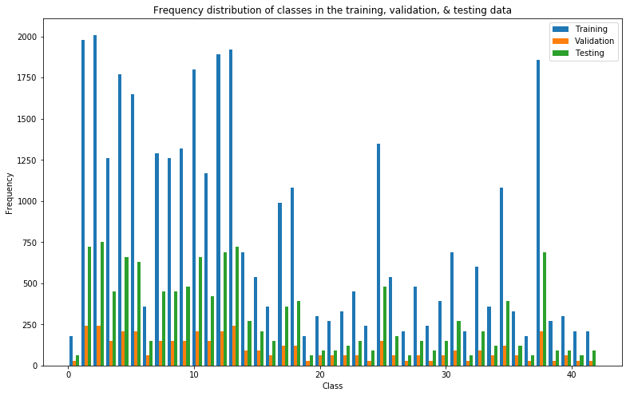

```python
from matplotlib.patches import Rectangle

plt.figure(figsize=(13,8))
#Plot histogram of distribution of classes within the training, validation, and testing sets
nums, bins, patches = plt.hist([y_train, y_valid, y_test], bins=n_classes,  label=["Training","Validation", "Testing"])
#create legend
plt.legend(loc=0)
plt.title("Frequency distribution of classes in the training, validation, & testing data")
plt.xlabel("Class")
plt.ylabel("Frequency");
plt.savefig('.\\figures\\visualexp1.jpg')
```

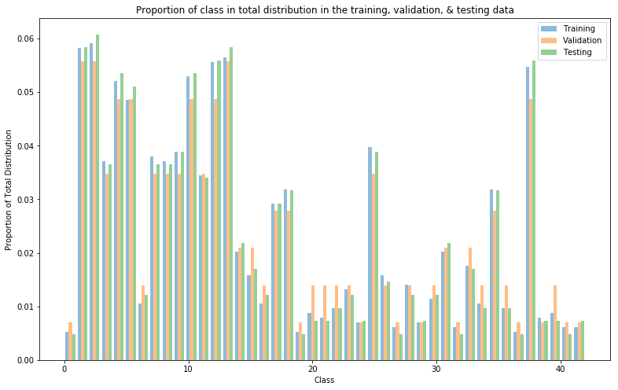

```python
plt.figure(figsize=(13,8))
#Plot normed histogram of the distribution of classes within the training, validation, and testing sets
n, bins, patches = plt.hist([y_train, y_valid, y_test], bins=n_classes, normed=1, alpha=0.5, label=["Training","Validation", "Testing"])
plt.legend(loc=0)
plt.title("Proportion of class in total distribution in the training, validation, & testing data")
plt.xlabel("Class")
plt.ylabel("Proportion of Total Distribution");
```

## Step 2: Design and Test a Model Architecture

Design and implement a deep learning model that learns to recognize traffic signs. Train and test your model on the [German Traffic Sign Dataset](http://benchmark.ini.rub.de/?section=gtsrb&subsection=dataset).

The LeNet-5 implementation shown in the classroom at the end of the CNN lesson is a solid starting point. You'll have to change the number of classes and possibly the preprocessing, but aside from that it's plug and play!

With the LeNet-5 solution from the lecture, you should expect a validation set accuracy of about 0.89. To meet specifications, the validation set accuracy will need to be at least 0.93. It is possible to get an even higher accuracy, but 0.93 is the minimum for a successful project submission.

There are various aspects to consider when thinking about this problem:

- Neural network architecture (is the network over or underfitting?)
- Play around preprocessing techniques (normalization, rgb to grayscale, etc)
- Number of examples per label (some have more than others).
- Generate fake data.

Here is an example of a [published baseline model on this problem](http://yann.lecun.com/exdb/publis/pdf/sermanet-ijcnn-11.pdf). It's not required to be familiar with the approach used in the paper but, it's good practice to try to read papers like these.

### Pre-process the Data Set (normalization, grayscale, etc.)

Minimally, the image data should be normalized so that the data has mean zero and equal variance. For image data, `(pixel - 128)/ 128` is a quick way to approximately normalize the data and can be used in this project.

Other pre-processing steps are optional. You can try different techniques to see if it improves performance.

Use the code cell (or multiple code cells, if necessary) to implement the first step of your project.

```python
### Preprocess the data here. It is required to normalize the data. Other preprocessing steps could include
### converting to grayscale, etc.
### Feel free to use as many code cells as needed.
import cv2

#Function to convert image to grayscale:
def grayscale(X):

    #Convert to grayscale using numpy
    #X_gry = np.sum(X/3.0, axis=3, keepdims=1)

    #Converting to grayscale using openCV library
    X_gry=[]

    for i in range(len(X)):
        img = X[i]
        img_gry = cv2.cvtColor(img, cv2.COLOR_BGR2GRAY)
        img_expanded = img_gry[:, :, np.newaxis]
        X_gry.append(img_expanded)

    X_gry = np.array(X_gry)

    return X_gry

#Function to normalize image:
def normalize(X):
    #X_norm = (X - 128)/128

    #Normalize using OpenCV
    X_norm=[]
    for i in range(len(X)):
        img = X[i]
        mean, std = cv2.meanStdDev(img)
        img = (img - mean)/std
        X_norm.append(img)

    X_norm = np.array(X_norm)

    assert (X.shape == X_norm.shape)

    return X_norm

#Function to rotate image about its centre:
def rotate(X_img, rot_angle, scale=1):
    rows,cols,channels = X_img.shape
    M = cv2.getRotationMatrix2D((cols/2,rows/2),rot_angle,scale)
    X_img_rot = cv2.warpAffine(X_img,M,(cols,rows))
    if channels == 1:
        X_img_rot = X_img_rot[:, :, np.newaxis]
    assert (X_img.shape == X_img_rot.shape)

    return X_img_rot


#Function to flip image:
#Flip_dir indicates the axis over which the image will be flipped. 0: x-axis, positive number: y axis, and negative number: x and y axes
def flip(X_img, flip_dir):
    assert (isinstance(flip_dir, int)), print("Flip_dir needs to be specified as an integer.\n")
    X_img_flipped = cv2.flip(X_img, flip_dir)
    rows,cols,channels = X_img.shape
    if channels == 1:
        X_img_flipped = X_img_flipped[:, :, np.newaxis]
    assert (X_img.shape == X_img_flipped.shape)

    return X_img_flipped


#Function to translate image:
def translate(X_img, pixel_x, pixel_y):
    rows,cols,channels = X_img.shape
    M = np.float32([[1,0,pixel_x],[0,1,pixel_y]])
    X_img_trans = cv2.warpAffine(X_img,M,(cols,rows))
    if channels == 1:
        X_img_trans = X_img_trans[:, :, np.newaxis]
    assert (X_img.shape == X_img_trans.shape)

    return X_img_trans

#Function to zoom. 'fctr' is the number of pixels to zoom in.
def zoom(X_img, fctr):
    rows,cols,channels = X_img.shape
    pts1 = np.float32([[fctr, fctr],[rows-fctr,fctr],[fctr,cols-fctr],[rows-fctr,cols-fctr]])
    pts2 = np.float32([[0,0],[rows,0],[0,cols],[rows,cols]])
    M = cv2.getPerspectiveTransform(pts1,pts2)
    X_img_zoom = cv2.warpPerspective(X_img,M,(rows,cols))
    if channels == 1:
        X_img_zoom = X_img_zoom[:, :, np.newaxis]
    assert (X_img.shape == X_img_zoom.shape)

    return X_img_zoom
```

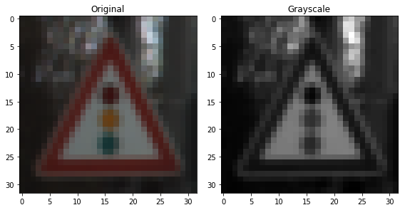

```python
#Convert to grayscale
X_train_gry = grayscale(X_train)
X_valid_gry = grayscale(X_valid)

#Plot an example
img_index = random.randint(0, len(X_train))
fig, ax = plt.subplots(1,2, figsize=(8,8))
ax = np.ravel(ax)
ax[0].imshow(X_train[img_index])
ax[0].set_title('Original')
ax[1].imshow(X_train_gry[img_index].squeeze(), cmap ='gray')
ax[1].set_title('Grayscale')
plt.tight_layout()
plt.savefig('.\\figures\\gray.jpg')
```

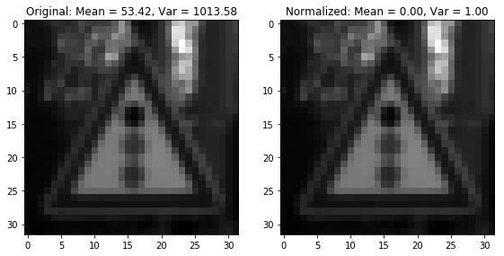

```python
#Normalize images around zero mean and equal variance
X_train_norm = normalize(X_train_gry)
X_valid_norm = normalize(X_valid_gry)

#Plot an example
fig, ax = plt.subplots(1,2, figsize=(8,8))
ax = np.ravel(ax)
ax[0].imshow(X_train_gry[img_index].squeeze(), cmap ='gray')
ax[0].set_title('Original: Mean = {:.2f}, Var = {:.2f}'.format(np.mean(X_train_gry[img_index]), np.var(X_train_gry[img_index])))
ax[1].imshow(X_train_norm[img_index].squeeze(), cmap ='gray')
ax[1].set_title('Normalized: Mean = {:.2f}, Var = {:.2f}'.format(np.mean(X_train_norm[img_index]), np.var(X_train_norm[img_index])))
plt.tight_layout()
plt.savefig('.\\figures\\normalize.jpg')
```

```
The shape of the original image:  (32, 32, 1)
The shape of the rotated image:  (32, 32, 1)
```

[figure not shown]

```python
#Example of rotated image
index = 500
X_rotated = rotate(X_train_norm[index], 10)

print("The shape of the original image: ", X_train_norm[index].shape)
print("The shape of the rotated image: ", X_rotated.shape)

plt.subplot(121), plt.imshow(np.squeeze(X_train_norm[index]), cmap = 'gray'), plt.title('Original')
plt.subplot(122), plt.imshow(np.squeeze(X_rotated), cmap = 'gray'), plt.title('Rotated');
plt.savefig('.\\figures\\rotated.jpg')
```

```
The shape of the original image:  (32, 32, 1)
The shape of the translated image:  (32, 32, 1)
```

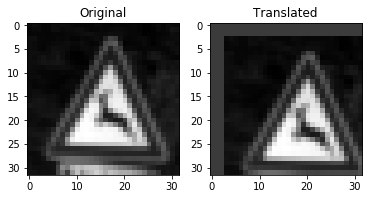

```python
#Example of rotated image
index = 500
X_translated = translate(X_train_norm[index], 3, 3)

print("The shape of the original image: ", X_train_norm[index].shape)
print("The shape of the translated image: ", X_translated.shape)

plt.subplot(121), plt.imshow(np.squeeze(X_train_norm[index]), cmap = 'gray'), plt.title('Original')
plt.subplot(122), plt.imshow(np.squeeze(X_translated), cmap = 'gray'), plt.title('Translated');
plt.savefig('.\\figures\\translated.jpg')
```

```
The shape of the original image:  (32, 32, 1)
The shape of the zoomed image:  (32, 32, 1)
```

[figure not shown]

```python
#Example of zoomed in image
index = 500
X_zoom = zoom(X_train_norm[index], 5)

print("The shape of the original image: ", X_train_norm[index].shape)
print("The shape of the zoomed image: ", X_zoom.shape)

plt.subplot(121), plt.imshow(np.squeeze(X_train_norm[index]), cmap = 'gray'), plt.title('Original')
plt.subplot(122), plt.imshow(np.squeeze(X_zoom), cmap = 'gray'), plt.title('Zoomed');
plt.savefig('.\\figures\\zoomed.jpg')
```

### Data Augmentation

In the following section, augmented images were added to the training set to make it more uniform in terms of class distribution and ultimately, improve the validation and test accuracy.

```python
def augment(X, y, n, nmax, classes, classes_dir):

    X_aug = []
    y_aug = []

    for i in range(len(X)):
        if y[i] not in classes:
            if n[y[i]] < nmax:


                #Perform rotation
                if y[i] in classes_dir:
                    #Rotation angles between -5 to 5 degrees to prevent flipping directions of signs suchs as "Keep left" or "Keep right"
                    rot_angle = random.randint(-5, 6)
                else:
                    rot_angle = random.randint(-10, 11)
                img = rotate(X[i], rot_angle)
                X_aug.append(img)
                y_aug.append(y[i])
                n[y[i]] += 1

                '''
                #Perform flip
                if y[i] not in classes_dir:
                    flip_dir = random.randint(-1, 2)
                    img = flip(X[i], flip_dir)
                    X_aug.append(img)
                    y_aug.append(y[i])
                    n[y[i]] += 1
                '''

                #Perform translation
                pixel_x = random.randint(-3, 4)
                pixel_y = random.randint(-3, 4)
                img = translate(X[i], pixel_x , pixel_y)
                X_aug.append(img)
                y_aug.append(y[i])
                n[y[i]] += 1

                #Perform zoom
                pixel_zoom = random.randint(1, 6)
                img = zoom(X[i], pixel_zoom)
                X_aug.append(img)
                y_aug.append(y[i])
                n[y[i]] += 1

                '''
                #Perform translation and rotation
                pixel_x = random.randint(-3, 4)
                pixel_y = random.randint(-3, 4)
                img = translate(X[i], pixel_x , pixel_y)
                if y[i] in classes_dir:
                    #Rotation angles between -5 to 5 degrees to prevent flipping directions of signs suchs as "Keep left" or "Keep right"
                    rot_angle = random.randint(-5, 5)
                else:
                    rot_angle = random.randint(-10, 11)
                img = rotate(img, rot_angle)
                X_aug.append(img)
                y_aug.append(y[i])
                n[y[i]] += 1

                #Perform zoom and rotation
                pixel_zoom = random.randint(1, 6)
                img = zoom(X[i], pixel_zoom)
                if y[i] in classes_dir:
                    #Rotation angles between -5 to 5 degrees to prevent flipping directions of signs suchs as "Keep left" or "Keep right"
                    rot_angle = random.randint(-5, 6)
                else:
                    rot_angle = random.randint(-10, 11)
                img = rotate(img, rot_angle)
                X_aug.append(img)
                y_aug.append(y[i])
                n[y[i]] += 1
                '''

                #Perform zoom and translate
                pixel_zoom = random.randint(1, 6)
                img = zoom(X[i], pixel_zoom)
                pixel_x = random.randint(-3, 4)
                pixel_y = random.randint(-3, 4)
                img = translate(img, pixel_x , pixel_y)
                X_aug.append(img)
                y_aug.append(y[i])
                n[y[i]] += 1


    X_aug = np.array(X_aug)
    y_aug = np.array(y_aug)

    return X_aug, y_aug
```

Creating augmented images in the training set.

```python
#Classes that are well representated in the training data
classes = [1,2,4,5,10,12,13,38]

#Classes which are direction specific (not to be flipped or rotated too much)
classes_dir = [19, 20, 24, 33, 34, 35, 36 , 37, 38, 39]

X_train_aug, y_train_aug = augment(X_train_norm, y_train, nums[0], 750, classes, classes_dir)
```

```python
print("The shape of the augmented training data is: ", X_train_aug.shape)
print("The shape of the augmented training data labels is: ", y_train_aug.shape)
```

```
The shape of the augmented training data is:  (10408, 32, 32, 1)
The shape of the augmented training data labels is:  (10408,)
```

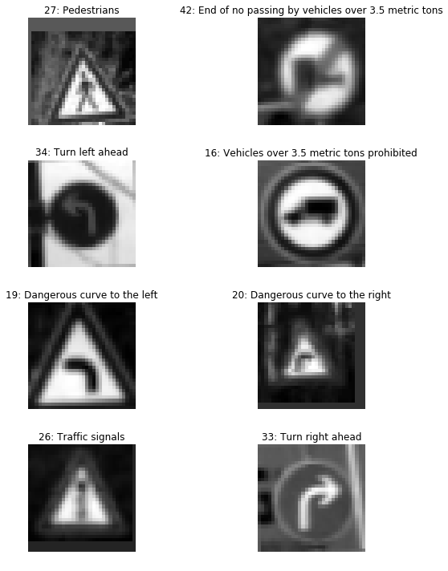

```python
fig, ax = plt.subplots(4,2, figsize=(10,10))
ax = np.ravel(ax)
for i in range(8):
    pic_num = random.randint(0, len(X_train_aug))
    ax[i].axis('off')
    ax[i].imshow(np.squeeze(X_train_aug[pic_num]), cmap ='gray')
    ax[i].set_title('{0}: {1}'.format(y_train_aug[pic_num], signs[y_train_aug[pic_num]]))
    plt.tight_layout()
```

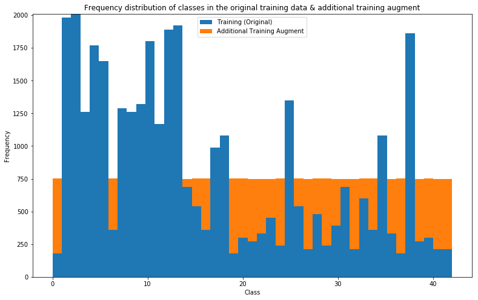

```python
plt.figure(figsize=(13,8))
#Plot histogram of distribution of classes within the training, validation, and testing sets
n, bins, patches = plt.hist([y_train, y_train_aug], bins=n_classes, stacked=True, label=["Training (Original)","Additional Training Augment"])
#create legend
plt.legend(loc=0)
plt.title("Frequency distribution of classes in the original training data & additional training augment")
plt.xlabel("Class")
plt.ylabel("Frequency");
plt.savefig('.\\figures\\augment.jpg')
```

```python
X_train_norm = np.concatenate((X_train_norm, X_train_aug), axis=0)
y_train = np.concatenate((y_train, y_train_aug), axis=0)
print("The shape of the total augmented training data: ", X_train_norm.shape)
print("The shape of the total augmented training data labels: ", y_train.shape)
```

```
The shape of the total augmented training data:  (45207, 32, 32, 1)
The shape of the total augmented training data labels:  (45207,)
```

### Model Architecture

```python
from sklearn.utils import shuffle

X_train = X_train_norm
X_valid = X_valid_norm

X_train, y_train = shuffle(X_train, y_train)

print("Training data has been shuffled")
```

```
Training data has been shuffled
```

```python
import tensorflow as tf
from tensorflow.contrib.layers import flatten

EPOCHS = 75
BATCH_SIZE = 100
```

### LeNet-5 Architecture

```python
def LeNet(x, n_classes):
    # Arguments used for tf.truncated_normal, randomly defines variables for the weights and biases for each layer
    mu = 0
    sigma = 0.1

    # Store layers weight & bias
    weights = {
    'wc1': tf.Variable(tf.truncated_normal([5, 5, 1, 6], mean=mu, stddev=sigma)),
    'wc2': tf.Variable(tf.truncated_normal([5, 5, 6, 16], mean=mu, stddev=sigma)),
    'wd1': tf.Variable(tf.truncated_normal([400, 120], mean=mu, stddev=sigma)),
    'wd2': tf.Variable(tf.truncated_normal([120, 84], mean=mu, stddev=sigma)),
    'out': tf.Variable(tf.truncated_normal([84, n_classes], mean=mu, stddev=sigma))}

    biases = {
    'bc1': tf.Variable(tf.truncated_normal([6], mean=mu, stddev=sigma)),
    'bc2': tf.Variable(tf.truncated_normal([16], mean=mu, stddev=sigma)),
    'bd1': tf.Variable(tf.truncated_normal([120], mean=mu, stddev=sigma)),
    'bd2': tf.Variable(tf.truncated_normal([84], mean=mu, stddev=sigma)),
    'out': tf.Variable(tf.truncated_normal([n_classes], mean=mu, stddev=sigma))}

    # Layer 1: Convolutional. Input = 32x32x1. Output = 28x28x6.
    conv1 = tf.nn.bias_add(tf.nn.conv2d(x, weights['wc1'], strides=[1, 1, 1, 1], padding='VALID'), biases['bc1'])

    # Activation.
    relu1 = tf.nn.relu(conv1)

    # Pooling. Input = 28x28x6. Output = 14x14x6.
    k=2
    pool1 = tf.nn.max_pool(relu1, ksize=[1, k, k, 1], strides=[1, k, k, 1], padding='SAME')

    # Layer 2: Convolutional. Output = 10x10x16.
    conv2 = tf.nn.bias_add(tf.nn.conv2d(pool1, weights['wc2'], strides=[1, 1, 1, 1], padding='VALID'), biases['bc2'])

    # Activation.
    relu2 = tf.nn.relu(conv2)

    # Pooling. Input = 10x10x16. Output = 5x5x16.
    k=2
    pool2 = tf.nn.max_pool(relu2, ksize=[1, k, k, 1], strides=[1, k, k, 1], padding='SAME')

    # Flatten. Input = 5x5x16. Output = 400.
    fc1 = flatten(pool2)

    # Layer 3: Fully Connected. Input = 400. Output = 120.
    fc1 = tf.add(tf.matmul(fc1, weights['wd1']), biases['bd1'])

    # Activation.
    relu3 = tf.nn.relu(fc1)

    # Layer 4: Fully Connected. Input = 120. Output = 84.
    fc2 = tf.add(tf.matmul(relu3, weights['wd2']), biases['bd2'])

    # Activation.
    relu4 = tf.nn.relu(fc2)

    # Layer 5: Fully Connected. Input = 84. Output = 43.
    logits = tf.add(tf.matmul(relu4, weights['out']), biases['out'])

    return logits
```

Modified LeNet architecture

```python
#Modified LeNet architecture
def LeNetmod(x, n_classes):
    # Arguments used for tf.truncated_normal, randomly defines variables for the weights and biases for each layer
    mu = 0
    sigma = 0.1

    # Store layers weight & bias
    weights = {
    'wc1': tf.Variable(tf.truncated_normal([5, 5, 1, 6], mean=mu, stddev=sigma)),
    'wc2': tf.Variable(tf.truncated_normal([5, 5, 6, 16], mean=mu, stddev=sigma)),
    'wd1': tf.Variable(tf.truncated_normal([400, 120], mean=mu, stddev=sigma)),
    'wd2': tf.Variable(tf.truncated_normal([120, 84], mean=mu, stddev=sigma)),
    'out': tf.Variable(tf.truncated_normal([84, n_classes], mean=mu, stddev=sigma))}

    biases = {
    'bc1': tf.Variable(tf.truncated_normal([6], mean=mu, stddev=sigma)),
    'bc2': tf.Variable(tf.truncated_normal([16], mean=mu, stddev=sigma)),
    'bd1': tf.Variable(tf.truncated_normal([120], mean=mu, stddev=sigma)),
    'bd2': tf.Variable(tf.truncated_normal([84], mean=mu, stddev=sigma)),
    'out': tf.Variable(tf.truncated_normal([n_classes], mean=mu, stddev=sigma))}

    # Layer 1: Convolutional. Input = 32x32x1. Output = 28x28x6.
    conv1 = tf.nn.bias_add(tf.nn.conv2d(x, weights['wc1'], strides=[1, 1, 1, 1], padding='VALID'), biases['bc1'])

    # Activation.
    relu1 = tf.nn.relu(conv1)

    # Pooling. Input = 28x28x6. Output = 14x14x6.
    k=2
    pool1 = tf.nn.max_pool(relu1, ksize=[1, k, k, 1], strides=[1, k, k, 1], padding='SAME')
    #pool1 = tf.nn.avg_pool(relu1, ksize=[1, k, k, 1], strides=[1, k, k, 1], padding='SAME')

    # Layer 2: Convolutional. Output = 10x10x16.
    conv2 = tf.nn.bias_add(tf.nn.conv2d(pool1, weights['wc2'], strides=[1, 1, 1, 1], padding='VALID'), biases['bc2'])

    # Activation.
    relu2 = tf.nn.relu(conv2)

    # Pooling. Input = 10x10x16. Output = 5x5x16.
    k=2
    pool2 = tf.nn.max_pool(relu2, ksize=[1, k, k, 1], strides=[1, k, k, 1], padding='SAME')
    #pool2 = tf.nn.avg_pool(relu2, ksize=[1, k, k, 1], strides=[1, k, k, 1], padding='SAME')

    # Flatten. Input = 5x5x16. Output = 400.
    fc1 = flatten(pool2)

    # Layer 3: Fully Connected. Input = 400. Output = 120.
    fc1 = tf.add(tf.matmul(fc1, weights['wd1']), biases['bd1'])

    # Activation.
    relu3 = tf.nn.relu(fc1)

    #Dropout
    drop1 = tf.nn.dropout(relu3, keep_prob)

    # Layer 4: Fully Connected. Input = 120. Output = 84.
    fc2 = tf.add(tf.matmul(drop1, weights['wd2']), biases['bd2'])

    # Activation.
    relu4 = tf.nn.relu(fc2)

    #Dropout
    drop2 = tf.nn.dropout(relu4, keep_prob)

    # Layer 5: Fully Connected. Input = 84. Output = 43.
    logits = tf.add(tf.matmul(drop2, weights['out']), biases['out'])

    return logits
```

```python
#Further Modified LeNet architecture
def LeNetmod2(x, n_classes):
    # Arguments used for tf.truncated_normal, randomly defines variables for the weights and biases for each layer
    mu = 0
    sigma = 0.1

    # Store layers weight & bias
    weights = {
    'wc1': tf.Variable(tf.truncated_normal([5, 5, 1, 30], mean=mu, stddev=sigma)),
    'wc2': tf.Variable(tf.truncated_normal([5, 5, 30, 40], mean=mu, stddev=sigma)),
    'wd1': tf.Variable(tf.truncated_normal([1000, 800], mean=mu, stddev=sigma)),
    'out': tf.Variable(tf.truncated_normal([800, n_classes], mean=mu, stddev=sigma))}

    biases = {
    'bc1': tf.Variable(tf.truncated_normal([30], mean=mu, stddev=sigma)),
    'bc2': tf.Variable(tf.truncated_normal([40], mean=mu, stddev=sigma)),
    'bd1': tf.Variable(tf.truncated_normal([800], mean=mu, stddev=sigma)),
    'out': tf.Variable(tf.truncated_normal([n_classes], mean=mu, stddev=sigma))}

    # Layer 1: Convolutional. Input = 32x32x1. Output = 28x28x6.
    conv1 = tf.nn.bias_add(tf.nn.conv2d(x, weights['wc1'], strides=[1, 1, 1, 1], padding='VALID'), biases['bc1'])

    # Activation.
    relu1 = tf.nn.tanh(conv1)

    # Pooling. Input = 28x28x6. Output = 14x14x6.
    k=2
    #pool1 = tf.nn.max_pool(relu1, ksize=[1, k, k, 1], strides=[1, k, k, 1], padding='SAME')
    pool1 = tf.nn.avg_pool(relu1, ksize=[1, k, k, 1], strides=[1, k, k, 1], padding='SAME')

    # Layer 2: Convolutional. Output = 10x10x16.
    conv2 = tf.nn.bias_add(tf.nn.conv2d(pool1, weights['wc2'], strides=[1, 1, 1, 1], padding='VALID'), biases['bc2'])

    # Activation.
    relu2 = tf.nn.tanh(conv2)

    # Pooling. Input = 10x10x16. Output = 5x5x16.
    k=2
    #pool2 = tf.nn.max_pool(relu2, ksize=[1, k, k, 1], strides=[1, k, k, 1], padding='SAME')
    pool2 = tf.nn.avg_pool(relu2, ksize=[1, k, k, 1], strides=[1, k, k, 1], padding='SAME')

    # Flatten. Input = 5x5x16. Output = 400.
    fc1 = flatten(pool2)

    '''
    # Layer 3: Fully Connected. Input = 400. Output = 120.
    fc1 = tf.add(tf.matmul(fc1, weights['wd1']), biases['bd1'])

    # Activation.
    relu3 = tf.nn.relu(fc1)

    #Dropout
    drop1 = tf.nn.dropout(relu3, keep_prob)

    # Layer 4: Fully Connected. Input = 120. Output = 84.
    fc2 = tf.add(tf.matmul(drop1, weights['wd2']), biases['bd2'])

    # Activation.
    relu4 = tf.nn.relu(fc2)
    '''

    # Layer 3: Fully Connected. Input = 400. Output = 300.
    fc1 = tf.add(tf.matmul(fc1, weights['wd1']), biases['bd1'])

    # Activation.
    relu3 = tf.nn.tanh(fc1)

    #Dropout
    drop2 = tf.nn.dropout(relu3, keep_prob)

    # Layer 4: Fully Connected. Input = 300. Output = 43.
    logits = tf.add(tf.matmul(drop2, weights['out']), biases['out'])

    return logits
```

Placeholders for batches of training images and labels as x, y. The training labels are one-hot encoded with the tf.one_hot function.

```python
x = tf.placeholder(tf.float32, (None, 32, 32, 1))
y = tf.placeholder(tf.int32, (None))
keep_prob = tf.placeholder(tf.float32) # probability to keep units
one_hot_y = tf.one_hot(y, n_classes)
```

### Train, Validate and Test the Model

A validation set can be used to assess how well the model is performing. A low accuracy on the training and validation sets imply underfitting. A high accuracy on the training set but low accuracy on the validation set implies overfitting.

Training Model

```python
### Train your model here.
### Calculate and report the accuracy on the training and validation set.
### Once a final model architecture is selected,
### the accuracy on the test set should be calculated and reported as well.
### Feel free to use as many code cells as needed.

#Learning rate
rate = 0.0009

logits = LeNetmod(x, n_classes)
cross_entropy = tf.nn.softmax_cross_entropy_with_logits_v2(labels=one_hot_y, logits=logits)
loss_operation = tf.reduce_mean(cross_entropy)
optimizer = tf.train.AdamOptimizer(learning_rate = rate)
training_operation = optimizer.minimize(loss_operation)
```

Evaluate accuracy:

```python
correct_prediction = tf.equal(tf.argmax(logits, 1), tf.argmax(one_hot_y, 1))
accuracy_operation = tf.reduce_mean(tf.cast(correct_prediction, tf.float32))
saver = tf.train.Saver()

def evaluate(X_data, y_data):
    num_examples = len(X_data)
    total_accuracy = 0
    sess = tf.get_default_session()
    for offset in range(0, num_examples, BATCH_SIZE):
        batch_x, batch_y = X_data[offset:offset+BATCH_SIZE], y_data[offset:offset+BATCH_SIZE]
        accuracy = sess.run(accuracy_operation, feed_dict={x: batch_x, y: batch_y, keep_prob: 1.0})
        total_accuracy += (accuracy * len(batch_x))
    return total_accuracy / num_examples
```

Train the model:

```python
valid_accuracy=[]
train_accuracy=[]
epoch_val=[]
```

```python
with tf.Session() as sess:
    sess.run(tf.global_variables_initializer())
    num_examples = len(X_train)

    print("Training...")
    print()
    for i in range(EPOCHS):
        X_train, y_train = shuffle(X_train, y_train)
        for offset in range(0, num_examples, BATCH_SIZE):
            end = offset + BATCH_SIZE
            batch_x, batch_y = X_train[offset:end], y_train[offset:end]
            sess.run(training_operation, feed_dict={x: batch_x, y: batch_y, keep_prob: 0.5})

        training_accuracy= evaluate(X_train, y_train)
        validation_accuracy = evaluate(X_valid, y_valid)
        train_accuracy.append(training_accuracy)
        valid_accuracy.append(validation_accuracy)
        epoch_val.append(i+1)
        print("EPOCH {} ...".format(i+1))
        print("Training Accuracy = {:.3f}".format(training_accuracy))
        print("Validation Accuracy = {:.3f}".format(validation_accuracy))
        print()

    saver.save(sess, './lenet')
    print("Model saved")
```

```
Training...

EPOCH 1 ...
Training Accuracy = 0.747
Validation Accuracy = 0.748

EPOCH 2 ...
Training Accuracy = 0.865
Validation Accuracy = 0.857

EPOCH 3 ...
Training Accuracy = 0.900
Validation Accuracy = 0.886

EPOCH 4 ...
Training Accuracy = 0.930
Validation Accuracy = 0.911

EPOCH 5 ...
Training Accuracy = 0.941
Validation Accuracy = 0.914

EPOCH 6 ...
Training Accuracy = 0.951
Validation Accuracy = 0.919

EPOCH 7 ...
Training Accuracy = 0.958
Validation Accuracy = 0.930

EPOCH 8 ...
Training Accuracy = 0.964
Validation Accuracy = 0.934

EPOCH 9 ...
Training Accuracy = 0.968
Validation Accuracy = 0.943

EPOCH 10 ...
Training Accuracy = 0.972
```

[output cut: 248 more lines]

```
Validation Accuracy = 0.973

EPOCH 73 ...
Training Accuracy = 0.999
Validation Accuracy = 0.969

EPOCH 74 ...
Training Accuracy = 0.999
Validation Accuracy = 0.973

EPOCH 75 ...
Training Accuracy = 0.998
Validation Accuracy = 0.968

Model saved
```

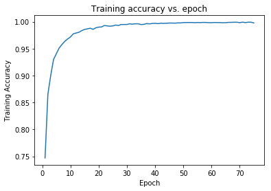

```python
plt.plot(epoch_val, train_accuracy)
plt.title("Training accuracy vs. epoch")
plt.xlabel("Epoch")
plt.ylabel("Training Accuracy")
#plt.ylim(0.9);
```

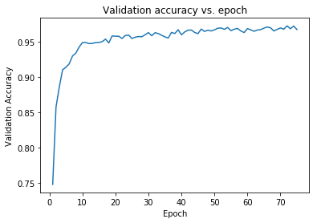

```python
plt.plot(epoch_val, valid_accuracy)
plt.title("Validation accuracy vs. epoch")
plt.xlabel("Epoch")
plt.ylabel("Validation Accuracy")
#plt.ylim(0.9);
```

Log:

- 17May2018:
  - Architecture: LeNet
  - Epochs: 100
  - Batch size: 128
  - Learning Rate: 0.001
  - mu: 0
  - sigma: 0.1
  - Accuracy: 0.948
- 18May2018:
  - Architecture: LeNet modified to add 2 dropout layers after the fully connected and activation layers
  - Epochs: 100
  - Batch size: 128
  - Learning Rate: 0.001
  - mu: 0
  - sigma: 0.1
  - keep_prob: 0.5
  - Accuracy: 0.961
  - Note: Increasing the learning rate to 0.01 reduced validation accuracy to fluctuate around 0.7-0.85.
  - Note: Decreasing the learning rate to 0.0005 gave a final accuracy of 0.965. Decreasing the learning rate to 0.0001 gave a final accuracy of 0.928 (the validation accuracy increased smoothly with less fluctuations, but the increase in validation accuracy happened slowly due to the low learning rate. This would require significantly higher epochs to reach the same level of accuracy as the faster learning rate of 0.001).
  - Note: Decreasing the batch size to 100 gave a final accuracy of 0.961.
  - Note: Increasing the batch size to 200 gave a final accuracy of 0.970.
  - Observation: The validation accuracy bounces around and makes marginal increases in accuracy as you increase epoch > 50. Make a plot of validation accuracy vs. epoch. Based on graph, the steepest increase in validation accuracy happens in the first 25 epochs. The fluctuations in the accuracy of the epoch become equal or greater than the marginal gains in the validation accuracy when epoch > 75. Choose epoch = 75, batch size = 200, and learning rate = 0.0005. Got final accuracy of 0.957.
- 21May2018: Augmented training set with rotated, flipped, and translated images.
  - Architecture: LeNet modified to add 2 dropout layers after the fully connected and activation layers
  - Epochs: 75
  - Batch size: 200
  - Learning Rate: 0.0005
  - mu: 0
  - sigma: 0.1
  - keep_prob: 0.5
  - Accuracy: 0.944
  - Note: Increasing the learning rate to 0.001 gave final accuracy of 0.957.
  - Note: Increasing the dropout keep_prob from 0.5 to 0.7 gave a final accuracy of 0.950.
- Trial 1: Baseline performance:
  - Architecture: LeNet (Original)
  - Data Augmentation: No
  - Epochs: 75
  - Batch size: 100
  - Learning Rate: 0.0009
  - mu: 0
  - sigma: 0.1
  - keep_prob: N/Ap
  - Accuracy: 0.932
- Trial 2: Baseline performance:
  - Architecture: LeNet modified to add 2 dropout layers after the fully connected and activation layers and average pooling layers instead of max pooling
  - Data Augmentation: No
  - Epochs: 75
  - Batch size: 100
  - Learning Rate: 0.0009
  - mu: 0
  - sigma: 0.1
  - keep_prob: 0.9
  - Accuracy: 0.946
  - Note: The validation accuracy vs. epoch graph hadn't levelled out at 75 epochs. Rerun with 100 epochs. Accuracy: 0.931 (Value fluctuated a lot).
  - Note: Changed keep_prob to 0.5. Accuracy at 75 epochs:0.959. Accuracy at 100 epochs: 0.963.
- Trial 3: Baseline performance:
  - Architecture: LeNet modified to add 2 dropout layers after the fully connected and activation layers and max pooling
  - Data Augmentation: No
  - Epochs: 75
  - Batch size: 100
  - Learning Rate: 0.0009
  - mu: 0
  - sigma: 0.1
  - keep_prob: 0.9
  - Accuracy: 0.939
  - Note: Accuracy: 0.934 at 100 epochs. (75 epochs sufficient)
  - Note: Changed keep_prob to 0.5. Accuracy at 75 epochs: 0.963 Accuracy at 100 epochs: 0.963.
  - Note: Augmented data to max 500 images per class to the training set only. Keep_prob = 0.5. Accuracy at 75 epochs: 0.949 Accuracy at 100 epochs: 0.959.
  - Note: Augmented data to max 750 images per class to the training set only. Keep_prob = 0.5. Accuracy at 75 epochs: 0.952 Accuracy at 100 epochs: 0.945.
- 22May2018: Lowered the rotation angle and removed flip operation in the augmented data set. Image operations with large changes were reducing the accuracy once the training set was augmented. Validation accuracy improved by approx. 1%.

Evaluate test set.

```python
#Convert test set to grayscale
X_test = grayscale(X_test)

#Normalize test set
X_test = normalize(X_test)
```

```python
with tf.Session() as sess:
    saver.restore(sess, "./lenet")

    test_accuracy = evaluate(X_test, y_test)
    print("Test Accuracy = {:.3f}".format(test_accuracy))
```

```
INFO:tensorflow:Restoring parameters from ./lenet
Test Accuracy = 0.950
```

## Step 3: Test a Model on New Images

To give yourself more insight into how your model is working, download at least five pictures of German traffic signs from the web and use your model to predict the traffic sign type.

You may find `signnames.csv` useful as it contains mappings from the class id (integer) to the actual sign name.

### Load and Output the Images

```python
### Load the images and plot them here.
### Feel free to use as many code cells as needed.
import os
os.listdir("NewTestImages/")
```

```
['1.jpg',
 '10.jpg',
 '2.jpg',
 '3.jpg',
 '4.jpg',
 '5.jpg',
 '6.jpg',
 '7.jpg',
 '8.jpg',
 '9.jpg',
 'labels.txt']
```

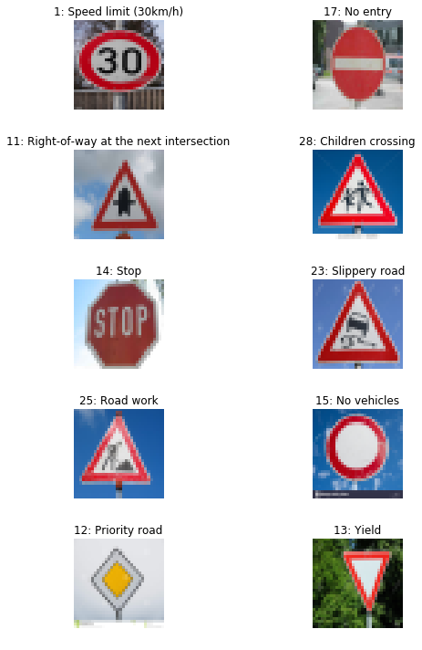

```python
#Reading in the images in the directory
from glob import glob
import matplotlib.image as mpimg
import cv2
from natsort import natsorted

images = []

for pic in natsorted(glob('NewTestImages/*.jpg')):
    image = mpimg.imread(pic)
    image = cv2.resize(image,(32,32), interpolation=cv2.INTER_AREA)
    images.append(image)

images = np.array(images)

labels = np.loadtxt('NewTestImages/labels.txt', dtype=int)

fig, ax = plt.subplots(5,2, figsize=(10,10))
ax = np.ravel(ax)
for i in range(10):
    ax[i].axis('off')
    ax[i].imshow(images[i])
    ax[i].set_title('{0}: {1}'.format(labels[i], signs[labels[i]]))
    plt.tight_layout()
plt.savefig('.\\figures\\newimages.jpg')
```

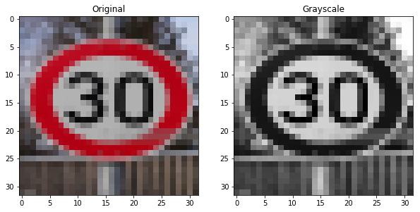

```python
#Convert to grayscale
images_gry = grayscale(images)

#Plot an example
img_index = random.randint(0, len(images_gry))
fig, ax = plt.subplots(1,2, figsize=(10,10))
ax = np.ravel(ax)
ax[0].imshow(images[img_index])
ax[0].set_title('Original')
ax[1].imshow(images_gry[img_index].squeeze(), cmap ='gray')
ax[1].set_title('Grayscale');
#plt.tight_layout()
```

[figure not shown]

```python
#Normalize images around zero mean and equal variance
images_norm = normalize(images_gry)

#Plot an example
fig, ax = plt.subplots(1,2, figsize=(10,10))
ax = np.ravel(ax)
ax[0].imshow(images_gry[img_index].squeeze(), cmap ='gray')
ax[0].set_title('Original: Mean = {:.2f}, Var = {:.2f}'.format(np.mean(images_gry[img_index]), np.var(images_gry[img_index])))
ax[1].imshow(images_norm[img_index].squeeze(), cmap ='gray')
ax[1].set_title('Normalized: Mean = {:.2f}, Var = {:.2f}'.format(np.mean(images_norm[img_index]), np.var(images_norm[img_index])))
plt.tight_layout()
```

```python
from copy import deepcopy
images_orig = deepcopy(images)
images = images_norm
```

### Predict the Sign Type for Each Image

```python
### Run the predictions here and use the model to output the prediction for each image.
### Make sure to pre-process the images with the same pre-processing pipeline used earlier.
### Feel free to use as many code cells as needed.
with tf.Session() as sess:
    saver.restore(sess, "./lenet")

    for i in range(len(images)):
        single_image=[]
        single_label=[]
        single_image.append(images[i])
        single_label.append(labels[i])
        test_accuracy = evaluate(single_image, single_label)
        if int(test_accuracy) == 1:
            print("Image {} was correctly classified".format(i+1))
        else:
            print("Image {} was incorrectly classified".format(i+1))
```

```
INFO:tensorflow:Restoring parameters from ./lenet
Image 1 was correctly classified
Image 2 was correctly classified
Image 3 was correctly classified
Image 4 was correctly classified
Image 5 was correctly classified
Image 6 was correctly classified
Image 7 was incorrectly classified
Image 8 was correctly classified
Image 9 was correctly classified
Image 10 was incorrectly classified
```

### Analyze Performance

```python
### Calculate the accuracy for these 5 new images.
### For example, if the model predicted 1 out of 5 signs correctly, it's 20% accurate on these new images.
with tf.Session() as sess:
    saver.restore(sess, "./lenet")

    test_accuracy = evaluate(images, labels)
    print("Test Accuracy = {:.3f}".format(test_accuracy))
```

```
INFO:tensorflow:Restoring parameters from ./lenet
Test Accuracy = 0.800
```

### Output Top 5 Softmax Probabilities For Each Image Found on the Web

For each of the new images, print out the model's softmax probabilities to show the **certainty** of the model's predictions (limit the output to the top 5 probabilities for each image). [`tf.nn.top_k`](https://www.tensorflow.org/versions/r0.12/api_docs/python/nn.html#top_k) could prove helpful here.

The example below demonstrates how tf.nn.top_k can be used to find the top k predictions for each image.

`tf.nn.top_k` will return the values and indices (class ids) of the top k predictions. So if k=3, for each sign, it'll return the 3 largest probabilities (out of a possible 43) and the correspoding class ids.

Take this numpy array as an example. The values in the array represent predictions. The array contains softmax probabilities for five candidate images with six possible classes. `tf.nn.top_k` is used to choose the three classes with the highest probability:

```
# (5, 6) array
a = np.array([[ 0.24879643,  0.07032244,  0.12641572,  0.34763842,  0.07893497,
         0.12789202],
       [ 0.28086119,  0.27569815,  0.08594638,  0.0178669 ,  0.18063401,
         0.15899337],
       [ 0.26076848,  0.23664738,  0.08020603,  0.07001922,  0.1134371 ,
         0.23892179],
       [ 0.11943333,  0.29198961,  0.02605103,  0.26234032,  0.1351348 ,
         0.16505091],
       [ 0.09561176,  0.34396535,  0.0643941 ,  0.16240774,  0.24206137,
         0.09155967]])
```

Running it through `sess.run(tf.nn.top_k(tf.constant(a), k=3))` produces:

```
TopKV2(values=array([[ 0.34763842,  0.24879643,  0.12789202],
       [ 0.28086119,  0.27569815,  0.18063401],
       [ 0.26076848,  0.23892179,  0.23664738],
       [ 0.29198961,  0.26234032,  0.16505091],
       [ 0.34396535,  0.24206137,  0.16240774]]), indices=array([[3, 0, 5],
       [0, 1, 4],
       [0, 5, 1],
       [1, 3, 5],
       [1, 4, 3]], dtype=int32))
```

Looking just at the first row we get `[ 0.34763842, 0.24879643, 0.12789202]`, you can confirm these are the 3 largest probabilities in `a`. You'll also notice `[3, 0, 5]` are the corresponding indices.

```python
### Print out the top five softmax probabilities for the predictions on the German traffic sign images found on the web.
### Feel free to use as many code cells as needed.
#Probabilities
prob  = tf.nn.softmax(logits)
top_prob = tf.nn.top_k(prob, 5)

with tf.Session() as sess:
    saver.restore(sess, "./lenet")
    probs = sess.run(prob, feed_dict={x: images, keep_prob: 1.0})
    maxprobs = sess.run(top_prob, feed_dict={x: images, keep_prob: 1.0})
```

```
INFO:tensorflow:Restoring parameters from ./lenet
```

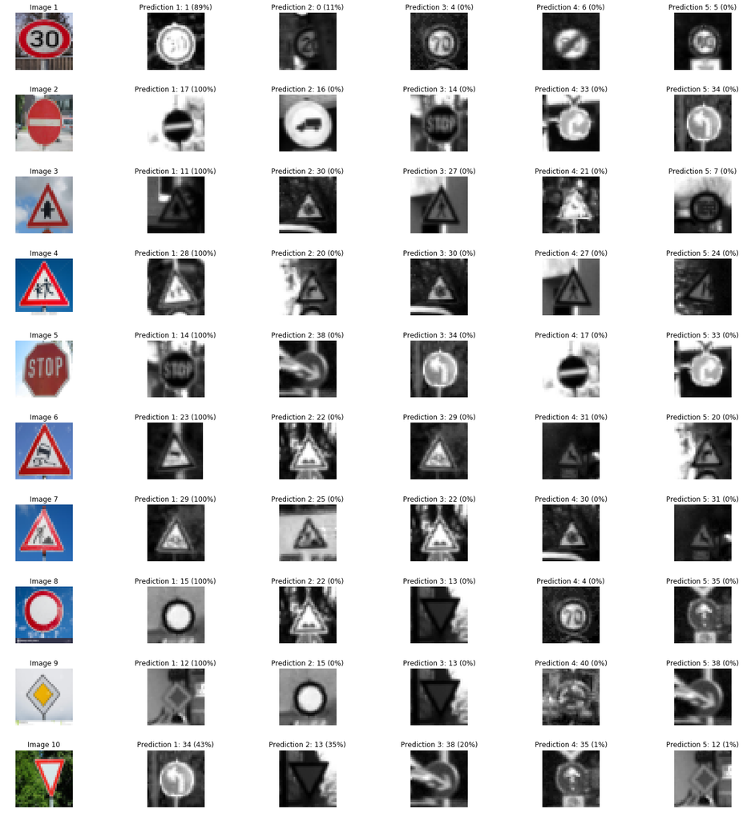

```python
fig, ax = plt.subplots(len(images),6, figsize=(20,20))
ax = np.ravel(ax)
for i in range(len(images_orig)):
    ax[6*i].axis('off')
    ax[6*i].imshow(images_orig[i])
    ax[6*i].set_title("Image {}".format(i+1))
    img_prob = maxprobs[0][i][0:5]
    img_indices = maxprobs[1][i][0:5]

    for j in range(0,5,1):
        index = np.argwhere(y_valid == img_indices[j])[0]
        ax[6*i+j+1].axis('off')
        ax[6*i+j+1].imshow(X_valid[index].squeeze(), cmap='gray')
        ax[6*i+j+1].set_title("Prediction {0}: {1} ({2:.0f}%)".format(j+1, int(y_valid[index]), 100*img_prob[j]))

    plt.tight_layout()
```

```python
for i in range(len(images_orig)):
    table = []
    img_prob = maxprobs[0][i][0:5]
    img_indices = maxprobs[1][i][0:5]
    print("Image {}".format(i+1))
    print("Probabilities\t|Prediction")
    for j in range(0,5):
        index = np.argwhere(y_valid == img_indices[j])[0]
        pred = str(signs[int(y_valid[index])])
        print("{:.2f}\t\t|{}".format(img_prob[j], pred))
        #print(img_prob[j],"\t","|", pred)
    print("\n")
```

```
Image 1
Probabilities	|Prediction
0.89		|Speed limit (30km/h)
0.11		|Speed limit (20km/h)
0.00		|Speed limit (70km/h)
0.00		|End of speed limit (80km/h)
0.00		|Speed limit (80km/h)


Image 2
Probabilities	|Prediction
1.00		|No entry
0.00		|Vehicles over 3.5 metric tons prohibited
0.00		|Stop
0.00		|Turn right ahead
0.00		|Turn left ahead


Image 3
Probabilities	|Prediction
1.00		|Right-of-way at the next intersection
0.00		|Beware of ice/snow
0.00		|Pedestrians
0.00		|Double curve
0.00		|Speed limit (100km/h)


Image 4
Probabilities	|Prediction
1.00		|Children crossing
0.00		|Dangerous curve to the right
0.00		|Beware of ice/snow
0.00		|Pedestrians
0.00		|Road narrows on the right


Image 5
Probabilities	|Prediction
1.00		|Stop
0.00		|Keep right
```

[output cut: 33 more lines]

```
Probabilities	|Prediction
1.00		|Priority road
0.00		|No vehicles
0.00		|Yield
0.00		|Roundabout mandatory
0.00		|Keep right


Image 10
Probabilities	|Prediction
0.43		|Turn left ahead
0.35		|Yield
0.20		|Keep right
0.01		|Ahead only
0.01		|Priority road
```

### Project Writeup

Once you have completed the code implementation, document your results in a project writeup using this [template](https://github.com/udacity/CarND-Traffic-Sign-Classifier-Project/blob/master/writeup_template.md) as a guide. The writeup can be in a markdown or pdf file.

## Step 4 (Optional): Visualize the Neural Network's State with Test Images

This Section is not required to complete but acts as an additional excersise for understaning the output of a neural network's weights. While neural networks can be a great learning device they are often referred to as a black box. We can understand what the weights of a neural network look like better by plotting their feature maps. After successfully training your neural network you can see what it's feature maps look like by plotting the output of the network's weight layers in response to a test stimuli image. From these plotted feature maps, it's possible to see what characteristics of an image the network finds interesting. For a sign, maybe the inner network feature maps react with high activation to the sign's boundary outline or to the contrast in the sign's painted symbol.

Provided for you below is the function code that allows you to get the visualization output of any tensorflow weight layer you want. The inputs to the function should be a stimuli image, one used during training or a new one you provided, and then the tensorflow variable name that represents the layer's state during the training process, for instance if you wanted to see what the LeNet lab's feature maps looked like for it's second convolutional layer you could enter conv2 as the tf_activation variable.

For an example of what feature map outputs look like, check out NVIDIA's results in their paper [End-to-End Deep Learning for Self-Driving Cars](https://devblogs.nvidia.com/parallelforall/deep-learning-self-driving-cars/) in the section Visualization of internal CNN State. NVIDIA was able to show that their network's inner weights had high activations to road boundary lines by comparing feature maps from an image with a clear path to one without. Try experimenting with a similar test to show that your trained network's weights are looking for interesting features, whether it's looking at differences in feature maps from images with or without a sign, or even what feature maps look like in a trained network vs a completely untrained one on the same sign image.

[figure not shown]

Your output should look something like this (above)

```python
### Visualize your network's feature maps here.
### Feel free to use as many code cells as needed.

# image_input: the test image being fed into the network to produce the feature maps
# tf_activation: should be a tf variable name used during your training procedure that represents the calculated state of a specific weight layer
# activation_min/max: can be used to view the activation contrast in more detail, by default matplot sets min and max to the actual min and max values of the output
# plt_num: used to plot out multiple different weight feature map sets on the same block, just extend the plt number for each new feature map entry

def outputFeatureMap(image_input, tf_activation, activation_min=-1, activation_max=-1 ,plt_num=1, name=''):
    # Here make sure to preprocess your image_input in a way your network expects
    # with size, normalization, ect if needed
    image_input = grayscale(image_input)
    image_input = normalize(image_input)
    # Note: x should be the same name as your network's tensorflow data placeholder variable
    # If you get an error tf_activation is not defined it may be having trouble accessing the variable from inside a function
    activation = tf_activation.eval(session=sess,feed_dict={x : image_input})
    featuremaps = activation.shape[3]
    plt.figure(plt_num, figsize=(15,15))
    plt.suptitle(name)
    for featuremap in range(featuremaps):
        plt.subplot(6,8, featuremap+1) # sets the number of feature maps to show on each row and column
        plt.title('FeatureMap ' + str(featuremap)) # displays the feature map number
        if activation_min != -1 & activation_max != -1:
            plt.imshow(activation[0,:,:, featuremap], interpolation="nearest", vmin =activation_min, vmax=activation_max, cmap="gray")
        elif activation_max != -1:
            plt.imshow(activation[0,:,:, featuremap], interpolation="nearest", vmax=activation_max, cmap="gray")
        elif activation_min !=-1:
            plt.imshow(activation[0,:,:, featuremap], interpolation="nearest", vmin=activation_min, cmap="gray")
        else:
            plt.imshow(activation[0,:,:, featuremap], interpolation="nearest", cmap="gray")
```

```python
#Modified LeNet architecture
#def LeNetmod(x, n_classes):
x = tf.placeholder(tf.float32, (1, 32, 32, 1))

# Arguments used for tf.truncated_normal, randomly defines variables for the weights and biases for each layer
mu = 0
sigma = 0.1

    # Store layers weight & bias
weights = {
'wc1': tf.Variable(tf.truncated_normal([5, 5, 1, 6], mean=mu, stddev=sigma)),
'wc2': tf.Variable(tf.truncated_normal([5, 5, 6, 16], mean=mu, stddev=sigma)),
'wd1': tf.Variable(tf.truncated_normal([400, 120], mean=mu, stddev=sigma)),
'wd2': tf.Variable(tf.truncated_normal([120, 84], mean=mu, stddev=sigma)),
'out': tf.Variable(tf.truncated_normal([84, n_classes], mean=mu, stddev=sigma))}

biases = {
'bc1': tf.Variable(tf.truncated_normal([6], mean=mu, stddev=sigma)),
'bc2': tf.Variable(tf.truncated_normal([16], mean=mu, stddev=sigma)),
'bd1': tf.Variable(tf.truncated_normal([120], mean=mu, stddev=sigma)),
'bd2': tf.Variable(tf.truncated_normal([84], mean=mu, stddev=sigma)),
'out': tf.Variable(tf.truncated_normal([n_classes], mean=mu, stddev=sigma))}

# Layer 1: Convolutional. Input = 32x32x1. Output = 28x28x6.
conv1 = tf.nn.bias_add(tf.nn.conv2d(x, weights['wc1'], strides=[1, 1, 1, 1], padding='VALID'), biases['bc1'])

# Activation.
relu1 = tf.nn.relu(conv1)

# Pooling. Input = 28x28x6. Output = 14x14x6.
k=2
pool1 = tf.nn.max_pool(relu1, ksize=[1, k, k, 1], strides=[1, k, k, 1], padding='SAME')
#pool1 = tf.nn.avg_pool(relu1, ksize=[1, k, k, 1], strides=[1, k, k, 1], padding='SAME')

# Layer 2: Convolutional. Output = 10x10x16.
conv2 = tf.nn.bias_add(tf.nn.conv2d(pool1, weights['wc2'], strides=[1, 1, 1, 1], padding='VALID'), biases['bc2'])

# Activation.
relu2 = tf.nn.relu(conv2)

# Pooling. Input = 10x10x16. Output = 5x5x16.
k=2
pool2 = tf.nn.max_pool(relu2, ksize=[1, k, k, 1], strides=[1, k, k, 1], padding='SAME')
#pool2 = tf.nn.avg_pool(relu2, ksize=[1, k, k, 1], strides=[1, k, k, 1], padding='SAME')

# Flatten. Input = 5x5x16. Output = 400.
fc1 = flatten(pool2)

# Layer 3: Fully Connected. Input = 400. Output = 120.
fc1 = tf.add(tf.matmul(fc1, weights['wd1']), biases['bd1'])

# Activation.
relu3 = tf.nn.relu(fc1)

#Dropout
drop1 = tf.nn.dropout(relu3, keep_prob)

# Layer 4: Fully Connected. Input = 120. Output = 84.
fc2 = tf.add(tf.matmul(drop1, weights['wd2']), biases['bd2'])

# Activation.
relu4 = tf.nn.relu(fc2)

#Dropout
drop2 = tf.nn.dropout(relu4, keep_prob)

# Layer 5: Fully Connected. Input = 84. Output = 43.
logits = tf.add(tf.matmul(drop2, weights['out']), biases['out'])

#    return logits
```

```python
images=[]
images.append(images_orig[0])
images = np.array(images)
```

```
INFO:tensorflow:Restoring parameters from ./lenet
```

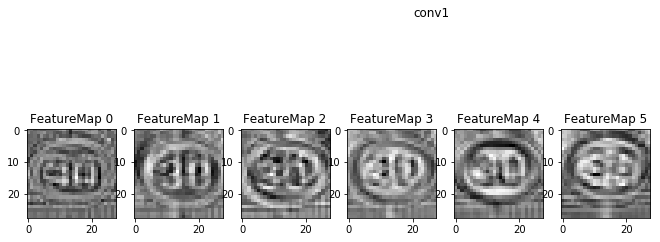

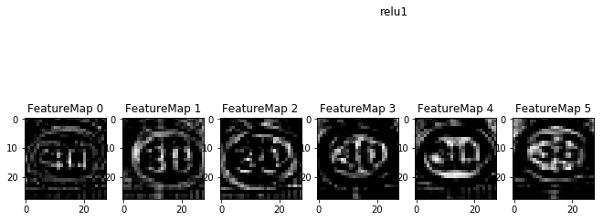

[figure not shown]

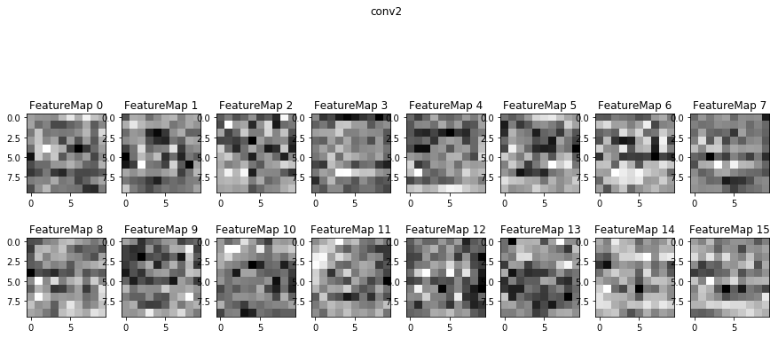

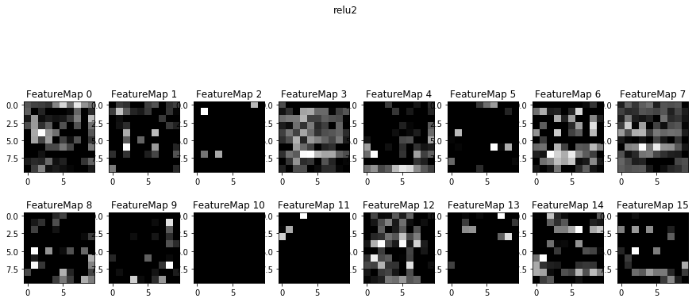

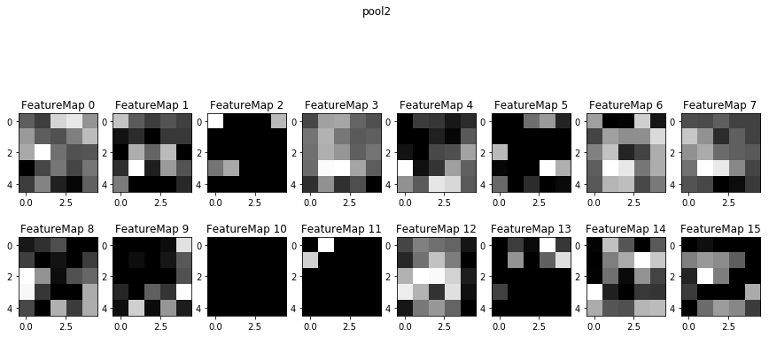

```python
#layers = [conv1, relu1, pool1, conv2, relu2, pool2, fc1, relu3, drop1, fc2, relu4, drop2, logits]
#layers_names = ['conv1', 'relu1', 'pool1', 'conv2', 'relu2', 'pool2', 'fc1', 'relu3', 'drop1', 'fc2', 'relu4', 'drop2', 'logits']
layers = [conv1, relu1, pool1, conv2, relu2, pool2]
layers_names = ['conv1', 'relu1', 'pool1', 'conv2', 'relu2', 'pool2']

with tf.Session() as sess:
    sess.run(tf.global_variables_initializer())
    saver.restore(sess, "./lenet")
    for i in range(len(layers)):
        outputFeatureMap(images, layers[i], plt_num=i, name = layers_names[i])
```

```python
images=[]
images.append(images_orig[9])
images = np.array(images)
```

```
INFO:tensorflow:Restoring parameters from ./lenet
```

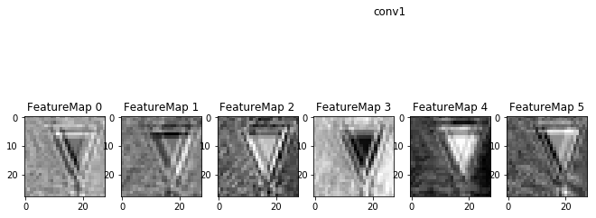

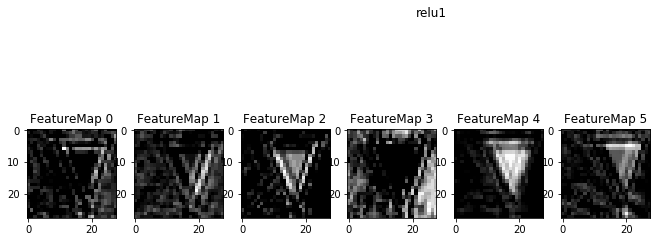

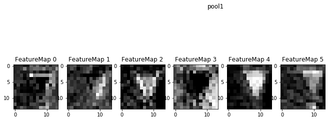

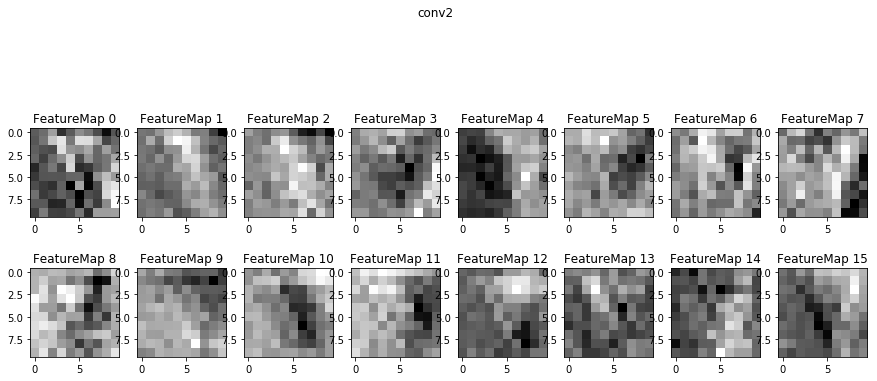

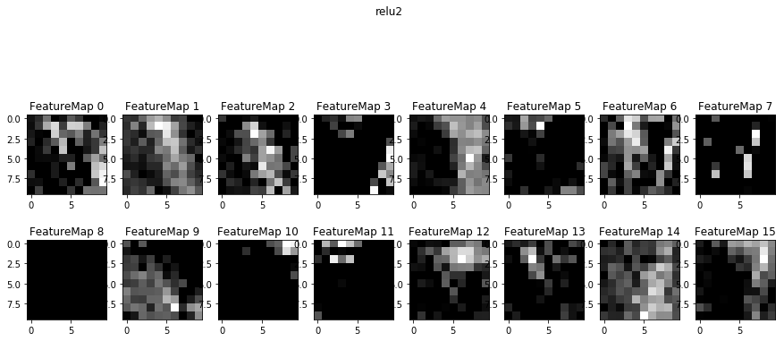

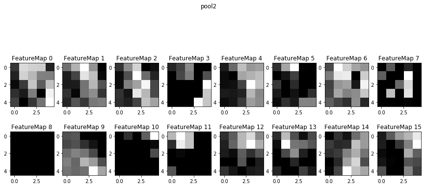

```python
#layers = [conv1, relu1, pool1, conv2, relu2, pool2, fc1, relu3, drop1, fc2, relu4, drop2, logits]
#layers_names = ['conv1', 'relu1', 'pool1', 'conv2', 'relu2', 'pool2', 'fc1', 'relu3', 'drop1', 'fc2', 'relu4', 'drop2', 'logits']
layers = [conv1, relu1, pool1, conv2, relu2, pool2]
layers_names = ['conv1', 'relu1', 'pool1', 'conv2', 'relu2', 'pool2']

with tf.Session() as sess:
    sess.run(tf.global_variables_initializer())
    saver.restore(sess, "./lenet")
    for i in range(len(layers)):
        outputFeatureMap(images, layers[i], plt_num=i, name = layers_names[i])
```